# M507_Methods_of_Prediction_Assessment_Carl_Jhon_Odicta_GH1043274

Submitted by: Carl Jhon D. Odicta

GH Number: GH 1043274

Module: Methods of Prediction

Module Code: M507A

Module Tutor: Prof. Mohammad Madhavi

Date Submitted: December 17, 2025

# Chest X-Ray Image Classification for Pneumonia Detection using Convolutional Neural Network

**I. Business Problem**

**Problem Statement**

Pneumonia remains a leading cause of mortality among young children in developing countries and elderly populations in developed regions (Ruuskanen et al., 2011). Although, despite the severity and commonality of this disease, it is very much treatable with today's technology. Treatment is significantly more effective when detected earlier but manual diagnosis even by seasoned doctors can take time and prone to human error, especially during busy healthcare settings. This is why it is essential to have the capability to detect this disease faster, earlier, and more accurately.

**Data Collection**

For this assessment, we will use the Kaggle Chest X-Ray Pneumonia Dataset, which contains labeled X-ray images of healthy patients and patients with pneumonia. Images includes variations in gender, age, and imaging conditions which reflects real-world scenarios.

**Machine Learning Task**

Given the problem statement and nature of our dataset, we can formulate this Machine Learning task as a **Binary Image Classification Problem**. The input to the model is a chest X-ray image, and the output is a probability score indicating whether the image corresponds to a Normal or Pneumonia case.

Convolutional Neural Networks (CNNs) are well suited for this task due to their ability to automatically learn hierarchical spatial features such as lung opacity, texture patterns, and structural abnormalities directly from image data.

**Benefits**

- Faster and more accurate identification of pneumonia cases which supports early clinical intervention
- Improves consistency of diagnosis by reducing human error
- Reduce workload for doctors/radiologists through automated screening
- Future studies can scale the framework of this study to detect other chest conditions/diseases

**II. Data Loading**

**Dataset**

The dataset we will be using comes from the Kaggle Chest X-Ray Pneumonia Dataset. It contains grayscale images and is pre-organized into labels of patients with and without pneumonia.

link: https://www.kaggle.com/datasets/paultimothymooney/chest-xray-pneumonia

**Load Dataset**

```python
# !pip install kaggle

import os
from pathlib import Path

!kaggle datasets download -d paultimothymooney/chest-xray-pneumonia --unzip

dataset_path = Path("chest_xray")

# Display
for split in ['train', 'test']:
    split_path = dataset_path / split
    print(f"\n{split.upper()} classes: {list(cls.name for cls in split_path.iterdir() if cls.is_dir())}")

    for cls_dir in split_path.iterdir():
        if cls_dir.is_dir():
            count = len(list(cls_dir.glob('*')))
            print(f"{cls_dir.name}: {count} images")
```

```
Dataset URL: https://www.kaggle.com/datasets/paultimothymooney/chest-xray-pneumonia
License(s): other
Downloading chest-xray-pneumonia.zip to /content
 99% 2.27G/2.29G [00:40<00:00, 38.3MB/s]
100% 2.29G/2.29G [00:41<00:00, 59.9MB/s]

TRAIN classes: ['PNEUMONIA', 'NORMAL']
PNEUMONIA: 3875 images
NORMAL: 1341 images

TEST classes: ['PNEUMONIA', 'NORMAL']
PNEUMONIA: 390 images
NORMAL: 234 images
```

**III. Exploratory Data Analysis (EDA)**

```python
import matplotlib.pyplot as plt
import numpy as np
import seaborn as sns
import pandas as pd
import cv2
from glob import glob
import shutil

base_dir = Path("chest_xray")
```

1. **Imbalance** - Let's check for data imbalance by counting the number of images per class from our original dataset

```
=== IMAGE COUNTS PER CLASS ===
```

|  | Split | Class | Count |
| --- | --- | --- | --- |
| 0 | train | NORMAL | 1341 |
| 1 | train | PNEUMONIA | 3875 |
| 2 | val | NORMAL | 8 |
| 3 | val | PNEUMONIA | 8 |
| 4 | test | NORMAL | 234 |
| 5 | test | PNEUMONIA | 390 |

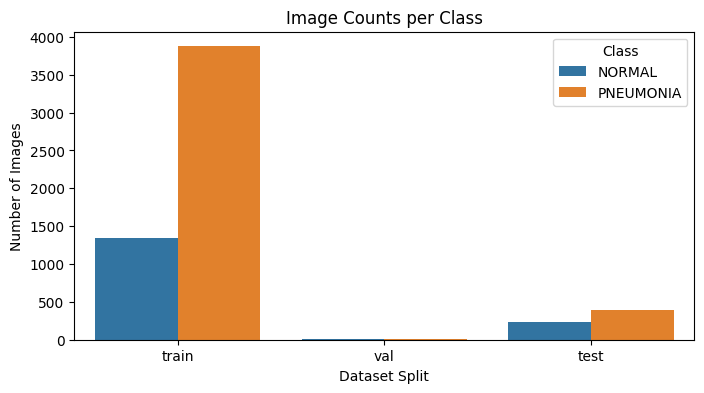

```python
data_summary = [
    [split, cls, len(list((base_dir / split / cls).glob("*")))]
    for split in ["train", "val", "test"]
    for cls in ["NORMAL", "PNEUMONIA"]
]

# Display
df_counts = pd.DataFrame(data_summary, columns=["Split", "Class", "Count"])

print("\n=== IMAGE COUNTS PER CLASS ===")
display(df_counts)

plt.figure(figsize=(8, 4))
sns.barplot(data=df_counts, x="Split", y="Count", hue="Class")
plt.title("Image Counts per Class")
plt.ylabel("Number of Images")
plt.xlabel("Dataset Split")
plt.show()
```

**EDA 1: Our Validation folder has very few datapoints.**

**EDA 2: There is imbalance in our train data.**

2. **Sample Images** - Let's display sample images to see what our data looks like

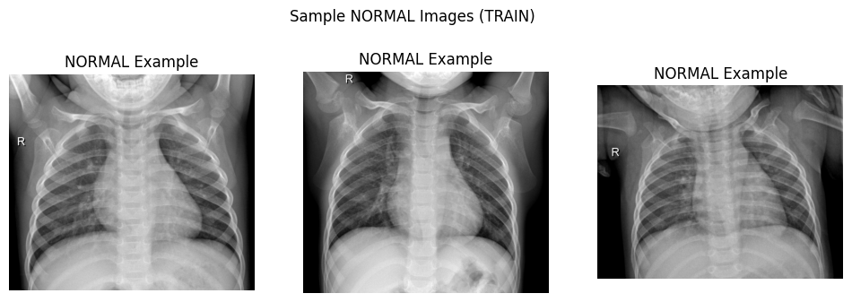

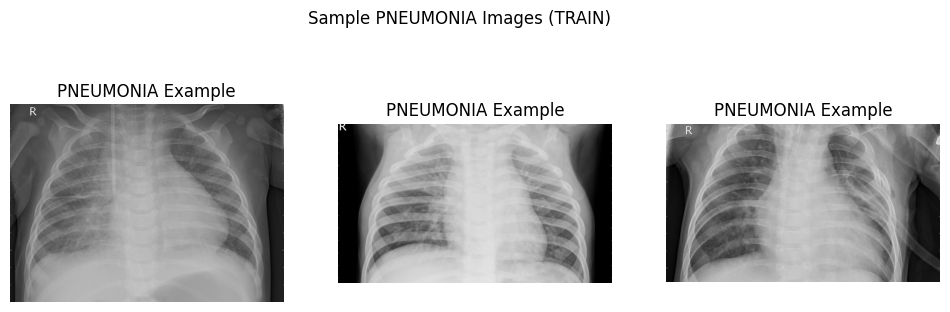

```python
def show_sample_images(cls, n=3):
    img_paths = glob(f"{base_dir}/train/{cls}/*.jpeg")
    sample_paths = np.random.choice(img_paths, n, replace=False)

    plt.figure(figsize=(12, 4))
    for i, img_path in enumerate(sample_paths):
        img = plt.imread(img_path)
        plt.subplot(1, n, i+1)
        plt.imshow(img, cmap="gray")
        plt.title(f"{cls} Example")
        plt.axis("off")
    plt.suptitle(f"Sample {cls} Images (TRAIN)")
    plt.show()

#Display
show_sample_images("NORMAL")
show_sample_images("PNEUMONIA")
```

**EDA 3: Inconsistent image size and quality**

Takeaways

1. The original validation set is too small for effective model tuning; therefore, training and validation data are re-split using a stratified approach.
2. Significant class imbalance exists in the training data, which is addressed using class weights and stratified split. Augmentation techniques like SMOTE is not advised when working with image data
3. Images vary in resolution and quality. Meaning we have to resize and normalize the images in our dataset to have a uniform consistent inputs.

**IV. Data Preprocessing**

To solve EDA 1, we merge train and val folders so that we can split again later into proper 80/20 split

```python
# Merge Train and Val Folders
train_dir = base_dir / "train"
val_dir   = base_dir / "val"

for cls in ["NORMAL", "PNEUMONIA"]:
    src_dir = val_dir / cls
    dst_dir = train_dir / cls

    for img_file in src_dir.glob("*"):
        dst_file = dst_dir / img_file.name

        counter = 1
        while dst_file.exists():
            dst_file = dst_dir / f"{img_file.stem}_{counter}{img_file.suffix}"
            counter += 1
        shutil.move(str(img_file), str(dst_file))

# Display
print("Merged validation images into the training folder.")

for cls in ["NORMAL", "PNEUMONIA"]:
    filenames = [f.name for f in (train_dir / cls).glob("*")]
    duplicates = pd.Series(filenames).duplicated().sum()
    print(f"Class {cls} - duplicates after merge: {duplicates}")

for cls in ["NORMAL", "PNEUMONIA"]:
    total = len(list((train_dir / cls).glob("*")))
    print(f"Class {cls} - total images after merge: {total}")
```

```
Merged validation images into the training folder.
Class NORMAL - duplicates after merge: 0
Class PNEUMONIA - duplicates after merge: 0
Class NORMAL - total images after merge: 1349
Class PNEUMONIA - total images after merge: 3883
```

We can solve EDA 2 and 3, and split our merged training data using ImageDataGenerator from Keras.

Using ImageDataGenerator we will resize all images to 224x224 pixels and normalize to [0,1] range. Data augmentation techniques will be applied to the training set to improve generalization, while the validation and test set will only be rescaled.

```python
#Split Data and Normalize

from tensorflow.keras.preprocessing.image import ImageDataGenerator

train_datagen = ImageDataGenerator(
    rescale=1./255,
    rotation_range=10,
    zoom_range=0.1,
    horizontal_flip=True,
    brightness_range=[0.8, 1.2],
    validation_split=0.2
)

val_datagen = ImageDataGenerator(
    rescale=1./255,
    validation_split=0.2
)

test_datagen = ImageDataGenerator(rescale=1./255)

  # Create Generators
train_data = train_datagen.flow_from_directory(
    train_dir,
    target_size=(224, 224),
    batch_size=32,
    class_mode='binary',
    subset='training',
    shuffle=True
)

val_data = val_datagen.flow_from_directory(
    train_dir,
    target_size=(224, 224),
    batch_size=32,
    class_mode='binary',
    subset='validation',
    shuffle=False
)

test_data = test_datagen.flow_from_directory(
    os.path.join(base_dir, "test"),
    target_size=(224, 224),
    batch_size=32,
    class_mode='binary',
    shuffle=False
)
```

```
Found 4187 images belonging to 2 classes.
Found 1045 images belonging to 2 classes.
Found 624 images belonging to 2 classes.
```

Class weights - will also be used during our training to help address imbalance. This means higher class weight will be assigned to the minority class (NORMAL) to penalize misclassification more heavily, encouraging the model to learn discriminative features for underrepresented samples

```python
#Class Weights

from sklearn.utils.class_weight import compute_class_weight

classes = train_data.classes
class_weights_array = compute_class_weight(
    class_weight='balanced',
    classes=np.unique(classes),
    y=classes
)
class_weights = {i: class_weights_array[i] for i in range(len(class_weights_array))}

#Display
print("Class weights:", class_weights)
```

```
Class weights: {0: np.float64(1.938425925925926), 1: np.float64(0.6738010943031864)}
```

Let's check our processed dataset before moving on into data modelling

```python
# Processed Data Check

def get_counts(generator):
    unique, counts = np.unique(generator.classes, return_counts=True)
    class_mapping = {v: k for k, v in generator.class_indices.items()}
    return {class_mapping[u]: c for u, c in zip(unique, counts)}


train_counts = get_counts(train_data)
val_counts   = get_counts(val_data)
test_counts  = get_counts(test_data)

# Display
summary_df = pd.DataFrame({
    "Split": ["Train", "Validation", "Test"],
    "NORMAL": [train_counts.get("NORMAL", 0), val_counts.get("NORMAL", 0), test_counts.get("NORMAL", 0)],
    "PNEUMONIA": [train_counts.get("PNEUMONIA", 0), val_counts.get("PNEUMONIA", 0), test_counts.get("PNEUMONIA", 0)]
})

summary_df["Total"] = summary_df["NORMAL"] + summary_df["PNEUMONIA"]

print("\nPost-preprocessing dataset summary:")
print(summary_df)
```

```
Post-preprocessing dataset summary:
        Split  NORMAL  PNEUMONIA  Total
0       Train    1080       3107   4187
1  Validation     269        776   1045
2        Test     234        390    624
```

**V. Data Modelling**

**Baseline CNN**

A standard CNN architecture comprising of:

- 3 Convolution Blocks with maxpooling(2x2), 3x3 kernels, ReLU as the activation function, and progressively increasing filters
- Flatten to convert learned feature maps into a vector which will be passed to a dense layer
- Dropout for regularization which is initially set at 0.5 but will be optimized later on.
- Dense output layer with sigmoid activation function to output probabilities from [0,1] since we are working on a binary classification problem.

Three convolutional blocks provides sufficient capacity to learn hierarchical features from X-ray images without a high risk of overfitting given the size of the dataset.

Optimizer = Adam optimizer will be used for its adaptive learning rate, fast convergence, and widespread usage in medical image classification. The initial learning rate of 1e-3 was selected as a starting point for experimentation..

Early Stopping will be used for the entire process so as to not remove the need to optimize epoch (will set initial_epoch at 25).

Checkpoints to monitor training.

```python
import tensorflow as tf
from tensorflow.keras.models import Sequential
from tensorflow.keras.layers import Conv2D, MaxPooling2D, Flatten, Dense, Dropout
from tensorflow.keras.optimizers import Adam
from tensorflow.keras.callbacks import EarlyStopping, ModelCheckpoint

# Baseline CNN Architecture
def build_baseline_cnn(input_shape=(224,224,3)):
    model = Sequential([
        Conv2D(32, (3,3), activation='relu', input_shape=input_shape),
        MaxPooling2D(2,2),

        Conv2D(64, (3,3), activation='relu'),
        MaxPooling2D(2,2),

        Conv2D(128, (3,3), activation='relu'),
        MaxPooling2D(2,2),

        Flatten(),
        Dense(128, activation='relu'),
        Dropout(0.5),
        Dense(1, activation='sigmoid')
    ])
    return model

baseline_cnn = build_baseline_cnn()
baseline_cnn.compile(
    optimizer=Adam(learning_rate=1e-3),
    loss='binary_crossentropy',
    metrics=['accuracy']
)

baseline_cnn.summary()

# Callbacks
early_stopping = EarlyStopping(
    monitor='val_loss',
    patience=5,
    restore_best_weights=True
)

checkpoint = ModelCheckpoint(
    "baseline_cnn_best.keras",
    monitor='val_loss',
    save_best_only=True,
    verbose=1
)

# Train Model
history_baseline = baseline_cnn.fit(
    train_data,
    validation_data=val_data,
    epochs=25,
    class_weight=class_weights,
    callbacks=[early_stopping, checkpoint]
)
```

```
Model: "sequential_1"
```

```
┏━━━━━━━━━━━━━━━━━━━━━━━━━━━━━━━━━┳━━━━━━━━━━━━━━━━━━━━━━━━┳━━━━━━━━━━━━━━━┓
┃ Layer (type)                    ┃ Output Shape           ┃       Param # ┃
┡━━━━━━━━━━━━━━━━━━━━━━━━━━━━━━━━━╇━━━━━━━━━━━━━━━━━━━━━━━━╇━━━━━━━━━━━━━━━┩
│ conv2d_3 (Conv2D)               │ (None, 222, 222, 32)   │           896 │
├─────────────────────────────────┼────────────────────────┼───────────────┤
│ max_pooling2d_3 (MaxPooling2D)  │ (None, 111, 111, 32)   │             0 │
├─────────────────────────────────┼────────────────────────┼───────────────┤
│ conv2d_4 (Conv2D)               │ (None, 109, 109, 64)   │        18,496 │
├─────────────────────────────────┼────────────────────────┼───────────────┤
│ max_pooling2d_4 (MaxPooling2D)  │ (None, 54, 54, 64)     │             0 │
├─────────────────────────────────┼────────────────────────┼───────────────┤
│ conv2d_5 (Conv2D)               │ (None, 52, 52, 128)    │        73,856 │
├─────────────────────────────────┼────────────────────────┼───────────────┤
│ max_pooling2d_5 (MaxPooling2D)  │ (None, 26, 26, 128)    │             0 │
├─────────────────────────────────┼────────────────────────┼───────────────┤
│ flatten_1 (Flatten)             │ (None, 86528)          │             0 │
├─────────────────────────────────┼────────────────────────┼───────────────┤
│ dense_2 (Dense)                 │ (None, 128)            │    11,075,712 │
├─────────────────────────────────┼────────────────────────┼───────────────┤
│ dropout_1 (Dropout)             │ (None, 128)            │             0 │
├─────────────────────────────────┼────────────────────────┼───────────────┤
│ dense_3 (Dense)                 │ (None, 1)              │           129 │
└─────────────────────────────────┴────────────────────────┴───────────────┘
```

```
 Total params: 11,169,089 (42.61 MB)
```

```
 Trainable params: 11,169,089 (42.61 MB)
```

```
 Non-trainable params: 0 (0.00 B)
```

```
132/132 ━━━━━━━━━━━━━━━━━━━━ 0s 640ms/step - accuracy: 0.7117 - loss: 0.4986
Epoch 1: val_loss improved from inf to 0.14721, saving model to baseline_cnn_best.keras
132/132 ━━━━━━━━━━━━━━━━━━━━ 101s 736ms/step - accuracy: 0.7125 - loss: 0.4977 - val_accuracy: 0.9380 - val_loss: 0.1472
132/132 ━━━━━━━━━━━━━━━━━━━━ 0s 619ms/step - accuracy: 0.9044 - loss: 0.2457
Epoch 2: val_loss did not improve from 0.14721
132/132 ━━━━━━━━━━━━━━━━━━━━ 90s 681ms/step - accuracy: 0.9043 - loss: 0.2458 - val_accuracy: 0.9104 - val_loss: 0.2285
132/132 ━━━━━━━━━━━━━━━━━━━━ 0s 617ms/step - accuracy: 0.9086 - loss: 0.2365
Epoch 3: val_loss did not improve from 0.14721
132/132 ━━━━━━━━━━━━━━━━━━━━ 91s 686ms/step - accuracy: 0.9087 - loss: 0.2364 - val_accuracy: 0.8322 - val_loss: 0.3891
132/132 ━━━━━━━━━━━━━━━━━━━━ 0s 619ms/step - accuracy: 0.9098 - loss: 0.2283
Epoch 4: val_loss did not improve from 0.14721
132/132 ━━━━━━━━━━━━━━━━━━━━ 90s 681ms/step - accuracy: 0.9098 - loss: 0.2282 - val_accuracy: 0.9247 - val_loss: 0.2089
132/132 ━━━━━━━━━━━━━━━━━━━━ 0s 619ms/step - accuracy: 0.9242 - loss: 0.1865
Epoch 5: val_loss improved from 0.14721 to 0.12840, saving model to baseline_cnn_best.keras
132/132 ━━━━━━━━━━━━━━━━━━━━ 91s 691ms/step - accuracy: 0.9242 - loss: 0.1865 - val_accuracy: 0.9552 - val_loss: 0.1284
132/132 ━━━━━━━━━━━━━━━━━━━━ 0s 619ms/step - accuracy: 0.9215 - loss: 0.2006
Epoch 6: val_loss did not improve from 0.12840
132/132 ━━━━━━━━━━━━━━━━━━━━ 90s 683ms/step - accuracy: 0.9215 - loss: 0.2007 - val_accuracy: 0.9418 - val_loss: 0.1677
132/132 ━━━━━━━━━━━━━━━━━━━━ 0s 621ms/step - accuracy: 0.9244 - loss: 0.1883
Epoch 7: val_loss did not improve from 0.12840
132/132 ━━━━━━━━━━━━━━━━━━━━ 91s 688ms/step - accuracy: 0.9245 - loss: 0.1882 - val_accuracy: 0.9504 - val_loss: 0.1386
132/132 ━━━━━━━━━━━━━━━━━━━━ 0s 618ms/step - accuracy: 0.9315 - loss: 0.1763
Epoch 8: val_loss improved from 0.12840 to 0.12228, saving model to baseline_cnn_best.keras
132/132 ━━━━━━━━━━━━━━━━━━━━ 91s 689ms/step - accuracy: 0.9315 - loss: 0.1762 - val_accuracy: 0.9571 - val_loss: 0.1223
132/132 ━━━━━━━━━━━━━━━━━━━━ 0s 621ms/step - accuracy: 0.9439 - loss: 0.1509
Epoch 9: val_loss did not improve from 0.12228
132/132 ━━━━━━━━━━━━━━━━━━━━ 91s 689ms/step - accuracy: 0.9439 - loss: 0.1511 - val_accuracy: 0.9485 - val_loss: 0.1552
132/132 ━━━━━━━━━━━━━━━━━━━━ 0s 619ms/step - accuracy: 0.9238 - loss: 0.1904
Epoch 10: val_loss did not improve from 0.12228
132/132 ━━━━━━━━━━━━━━━━━━━━ 91s 687ms/step - accuracy: 0.9239 - loss: 0.1902 - val_accuracy: 0.9056 - val_loss: 0.2549
132/132 ━━━━━━━━━━━━━━━━━━━━ 0s 620ms/step - accuracy: 0.9300 - loss: 0.1747
Epoch 11: val_loss improved from 0.12228 to 0.11452, saving model to baseline_cnn_best.keras
132/132 ━━━━━━━━━━━━━━━━━━━━ 91s 692ms/step - accuracy: 0.9301 - loss: 0.1746 - val_accuracy: 0.9619 - val_loss: 0.1145
132/132 ━━━━━━━━━━━━━━━━━━━━ 0s 617ms/step - accuracy: 0.9481 - loss: 0.1433
Epoch 12: val_loss did not improve from 0.11452
132/132 ━━━━━━━━━━━━━━━━━━━━ 90s 685ms/step - accuracy: 0.9481 - loss: 0.1433 - val_accuracy: 0.9533 - val_loss: 0.1257
132/132 ━━━━━━━━━━━━━━━━━━━━ 0s 622ms/step - accuracy: 0.9429 - loss: 0.1623
Epoch 13: val_loss did not improve from 0.11452
132/132 ━━━━━━━━━━━━━━━━━━━━ 91s 689ms/step - accuracy: 0.9429 - loss: 0.1621 - val_accuracy: 0.9380 - val_loss: 0.1564
132/132 ━━━━━━━━━━━━━━━━━━━━ 0s 613ms/step - accuracy: 0.9500 - loss: 0.1325
Epoch 14: val_loss did not improve from 0.11452
132/132 ━━━━━━━━━━━━━━━━━━━━ 90s 681ms/step - accuracy: 0.9500 - loss: 0.1325 - val_accuracy: 0.9523 - val_loss: 0.1399
132/132 ━━━━━━━━━━━━━━━━━━━━ 0s 623ms/step - accuracy: 0.9481 - loss: 0.1418
Epoch 15: val_loss did not improve from 0.11452
132/132 ━━━━━━━━━━━━━━━━━━━━ 91s 688ms/step - accuracy: 0.9481 - loss: 0.1418 - val_accuracy: 0.9609 - val_loss: 0.1272
132/132 ━━━━━━━━━━━━━━━━━━━━ 0s 614ms/step - accuracy: 0.9449 - loss: 0.1376
Epoch 16: val_loss did not improve from 0.11452
132/132 ━━━━━━━━━━━━━━━━━━━━ 90s 682ms/step - accuracy: 0.9449 - loss: 0.1377 - val_accuracy: 0.9333 - val_loss: 0.1981
```

**Experimentation**

From our baseline CNN model we will conduct 'experiments' by sequentially adjusting the model's architecture and hyperparameters one-by-one while recording and comparing the **runtime/speed** and **val_accuracy** of each step to come up with our 'best model'

Structure of the Experiments:

- Compare with Transfer Learning (Resnet50)
- Architecture - Ensure we get the right and enough network capacity to learn features
- Regularization - To Control Overfitting
- Optimization - Hyperparameter Tuning

[figure not shown]

Despite several experimentations, the final model was just the baseline model with batch normalization, and learning rate scheduler and class weights applied.

Sometimes, the simplier model is just better and more practical to use

**Final Model**

```python
import tensorflow as tf
from tensorflow.keras import layers, models, optimizers, callbacks

# Configurations
IMG_SIZE = (224, 224)
LEARNING_RATE = 1e-3
EPOCHS = 25
MODEL_PATH = "final_cnn_best.keras"

# Architecture
final_cnn = models.Sequential([
    layers.Input(shape=(*IMG_SIZE, 3)),

    layers.Conv2D(32, (3, 3), activation='relu'),
    layers.BatchNormalization(),
    layers.MaxPooling2D(pool_size=(2, 2)),

    layers.Conv2D(64, (3, 3), activation='relu'),
    layers.BatchNormalization(),
    layers.MaxPooling2D(pool_size=(2, 2)),

    layers.Conv2D(128, (3, 3), activation='relu'),
    layers.BatchNormalization(),
    layers.MaxPooling2D(pool_size=(2, 2)),

    layers.Flatten(),
    layers.Dense(128, activation='relu'),
    layers.Dropout(0.5),

    layers.Dense(1, activation='sigmoid')
])

# Compile
final_cnn.compile(
    optimizer=optimizers.Adam(learning_rate=LEARNING_RATE),
    loss='binary_crossentropy',
    metrics=['accuracy']
)

final_cnn.summary()

# Callbacks
early_stopping = callbacks.EarlyStopping(
    monitor='val_loss',
    patience=5,
    restore_best_weights=True
)

model_checkpoint = callbacks.ModelCheckpoint(
    MODEL_PATH,
    monitor='val_loss',
    save_best_only=True
)

lr_scheduler = callbacks.ReduceLROnPlateau(
    monitor='val_loss',
    factor=0.3,
    patience=3,
    min_lr=1e-6
)

# Train
history_final = final_cnn.fit(
    train_data,
    validation_data=val_data,
    epochs=EPOCHS,
    class_weight=class_weights,
    callbacks=[early_stopping, model_checkpoint, lr_scheduler]
)
```

```
Model: "sequential"
```

```
┏━━━━━━━━━━━━━━━━━━━━━━━━━━━━━━━━━┳━━━━━━━━━━━━━━━━━━━━━━━━┳━━━━━━━━━━━━━━━┓
┃ Layer (type)                    ┃ Output Shape           ┃       Param # ┃
┡━━━━━━━━━━━━━━━━━━━━━━━━━━━━━━━━━╇━━━━━━━━━━━━━━━━━━━━━━━━╇━━━━━━━━━━━━━━━┩
│ conv2d (Conv2D)                 │ (None, 222, 222, 32)   │           896 │
├─────────────────────────────────┼────────────────────────┼───────────────┤
│ batch_normalization             │ (None, 222, 222, 32)   │           128 │
│ (BatchNormalization)            │                        │               │
├─────────────────────────────────┼────────────────────────┼───────────────┤
│ max_pooling2d (MaxPooling2D)    │ (None, 111, 111, 32)   │             0 │
├─────────────────────────────────┼────────────────────────┼───────────────┤
│ conv2d_1 (Conv2D)               │ (None, 109, 109, 64)   │        18,496 │
├─────────────────────────────────┼────────────────────────┼───────────────┤
│ batch_normalization_1           │ (None, 109, 109, 64)   │           256 │
│ (BatchNormalization)            │                        │               │
├─────────────────────────────────┼────────────────────────┼───────────────┤
│ max_pooling2d_1 (MaxPooling2D)  │ (None, 54, 54, 64)     │             0 │
├─────────────────────────────────┼────────────────────────┼───────────────┤
│ conv2d_2 (Conv2D)               │ (None, 52, 52, 128)    │        73,856 │
├─────────────────────────────────┼────────────────────────┼───────────────┤
│ batch_normalization_2           │ (None, 52, 52, 128)    │           512 │
│ (BatchNormalization)            │                        │               │
├─────────────────────────────────┼────────────────────────┼───────────────┤
│ max_pooling2d_2 (MaxPooling2D)  │ (None, 26, 26, 128)    │             0 │
├─────────────────────────────────┼────────────────────────┼───────────────┤
│ flatten (Flatten)               │ (None, 86528)          │             0 │
├─────────────────────────────────┼────────────────────────┼───────────────┤
│ dense (Dense)                   │ (None, 128)            │    11,075,712 │
├─────────────────────────────────┼────────────────────────┼───────────────┤
│ dropout (Dropout)               │ (None, 128)            │             0 │
├─────────────────────────────────┼────────────────────────┼───────────────┤
│ dense_1 (Dense)                 │ (None, 1)              │           129 │
└─────────────────────────────────┴────────────────────────┴───────────────┘
```

```
 Total params: 11,169,985 (42.61 MB)
```

```
 Trainable params: 11,169,537 (42.61 MB)
```

```
 Non-trainable params: 448 (1.75 KB)
```

```
131/131 ━━━━━━━━━━━━━━━━━━━━ 117s 816ms/step - accuracy: 0.7722 - loss: 4.5693 - val_accuracy: 0.7426 - val_loss: 31.4603 - learning_rate: 0.0010
131/131 ━━━━━━━━━━━━━━━━━━━━ 97s 741ms/step - accuracy: 0.8867 - loss: 0.3273 - val_accuracy: 0.7426 - val_loss: 10.2013 - learning_rate: 0.0010
131/131 ━━━━━━━━━━━━━━━━━━━━ 96s 734ms/step - accuracy: 0.8924 - loss: 0.3374 - val_accuracy: 0.7435 - val_loss: 4.6449 - learning_rate: 0.0010
131/131 ━━━━━━━━━━━━━━━━━━━━ 96s 729ms/step - accuracy: 0.9109 - loss: 0.2700 - val_accuracy: 0.9043 - val_loss: 0.3231 - learning_rate: 0.0010
131/131 ━━━━━━━━━━━━━━━━━━━━ 95s 729ms/step - accuracy: 0.9213 - loss: 0.2385 - val_accuracy: 0.8517 - val_loss: 0.3690 - learning_rate: 0.0010
131/131 ━━━━━━━━━━━━━━━━━━━━ 96s 734ms/step - accuracy: 0.9233 - loss: 0.2230 - val_accuracy: 0.9608 - val_loss: 0.1009 - learning_rate: 0.0010
131/131 ━━━━━━━━━━━━━━━━━━━━ 94s 720ms/step - accuracy: 0.9364 - loss: 0.2049 - val_accuracy: 0.5531 - val_loss: 12.7197 - learning_rate: 0.0010
131/131 ━━━━━━━━━━━━━━━━━━━━ 93s 709ms/step - accuracy: 0.8932 - loss: 0.3179 - val_accuracy: 0.9579 - val_loss: 0.2210 - learning_rate: 0.0010
131/131 ━━━━━━━━━━━━━━━━━━━━ 94s 717ms/step - accuracy: 0.9149 - loss: 0.3583 - val_accuracy: 0.7445 - val_loss: 5.5366 - learning_rate: 0.0010
131/131 ━━━━━━━━━━━━━━━━━━━━ 94s 716ms/step - accuracy: 0.9332 - loss: 0.1969 - val_accuracy: 0.8325 - val_loss: 0.4834 - learning_rate: 3.0000e-04
131/131 ━━━━━━━━━━━━━━━━━━━━ 93s 711ms/step - accuracy: 0.9463 - loss: 0.1770 - val_accuracy: 0.9617 - val_loss: 0.1175 - learning_rate: 3.0000e-04
```

The final model was selected based on the best balance between validation accuracy, training stability, and computational efficiency.

**VI. Evaluation**

**Threshold adjustment**

Pneumonia detection is a screening task, this missing a case (false negative) is clinically more dangerous, whereas a false positive is less harmful because these cases could still be caught with additional testing. Therefore, recall is generally considered more critical than precision in most medical application.

**To prioritize recall, the classification threshold will be adjusted to 0.35.** This is consistent with medical ML literature and ensures that missed pneumonia cases are minimized while keeping false positives at an acceptable level.

```python
# Imports

import numpy as np
import tensorflow as tf

from sklearn.metrics import (
    confusion_matrix,
    accuracy_score,
    precision_score,
    recall_score,
    f1_score,
    roc_auc_score,
    roc_curve
)

import matplotlib.pyplot as plt
import seaborn as sns
```

**Confusion matrix**

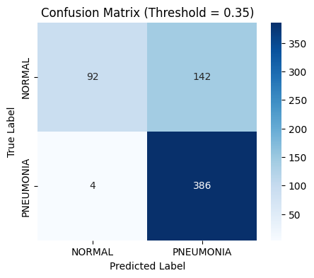

```python
cm = confusion_matrix(y_true, y_pred)

plt.figure(figsize=(5, 4))
sns.heatmap(
    cm,
    annot=True,
    fmt="d",
    cmap="Blues",
    xticklabels=["NORMAL", "PNEUMONIA"],
    yticklabels=["NORMAL", "PNEUMONIA"]
)

plt.xlabel("Predicted Label")
plt.ylabel("True Label")
plt.title("Confusion Matrix (Threshold = 0.35)")
plt.show()
```

Only 4 pneumonia cases were missed which is very low, and 142 false positives which is acceptable in screening context.

**Evaluation Metrics**

Using the numbers from the confusion matrix we calculate the accuracy, precision, recall, and f1-score.

```python
accuracy  = accuracy_score(y_true, y_pred)
precision = precision_score(y_true, y_pred)
recall    = recall_score(y_true, y_pred)
f1        = f1_score(y_true, y_pred)

print("=== Classification Metrics ===")
print(f"Accuracy : {accuracy:.4f}")
print(f"Precision: {precision:.4f}")
print(f"Recall   : {recall:.4f}")
print(f"F1-score : {f1:.4f}")
```

```
=== Classification Metrics ===
Accuracy : 0.7660
Precision: 0.7311
Recall   : 0.9897
F1-score : 0.8410
```

The recall of almost 99% ensures that almost all pneumonia cases are correctly identified which is more important in clinical setting. Accuracy alone is misleading due to class imbalance.

**Metrics at default threshold**

Threshold = 0.5

```python
y_pred_05 = (y_probs >= 0.5).astype(int)

print("\n=== Metrics at Threshold = 0.5 ===")
print(f"Accuracy : {accuracy_score(y_true, y_pred_05):.4f}")
print(f"Precision: {precision_score(y_true, y_pred_05):.4f}")
print(f"Recall   : {recall_score(y_true, y_pred_05):.4f}")
print(f"F1-score : {f1_score(y_true, y_pred_05):.4f}")
```

```
=== Metrics at Threshold = 0.5 ===
Accuracy : 0.7917
Precision: 0.7559
Recall   : 0.9846
F1-score : 0.8552
```

Slightly lower accuracy and precision is acceptable to maximize recall

**ROC Curve / AUC**

The ROC curve visualizes the trade-off between true positive rate and false positive rate across thresholds.

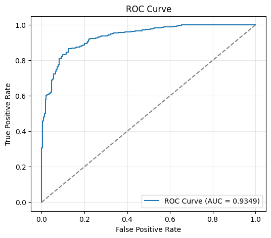

```python
roc_auc = roc_auc_score(y_true, y_probs)
fpr, tpr, thresholds = roc_curve(y_true, y_probs)

plt.figure(figsize=(6, 5))
plt.plot(fpr, tpr, label=f"ROC Curve (AUC = {roc_auc:.4f})")
plt.plot([0, 1], [0, 1], linestyle="--", color="gray")

plt.xlabel("False Positive Rate")
plt.ylabel("True Positive Rate")
plt.title("ROC Curve")
plt.legend(loc="lower right")
plt.grid(alpha=0.3)
plt.show()
```

```python
print(f"ROC AUC Score: {roc_auc:.4f}")
```

```
ROC AUC Score: 0.9349
```

The final model achieves an AUC of 0.9349, which indicates that the model can reliably distinguish between normal and pneumonia cases

**VII. Final Discussion**

**Model Strengths**

**Limitations**

- Dataset Limitation - The Kaggle Chest X-Ray dataset may not fully capture variations across populations, imaging equipment, or disease severity.
- Explanabality and Interpretability - CNNs are inherently complex models which may be difficult to understand and explain to healthcare professionals. This can be adressed visual explanations like grad-cam but was not able to implement it in this pipeline due to GPU limits. Good to implement for future improvements
- False Positives - Relatively high false positive meaning some normal cases are misclassified as pneumonia which may increase unnecessary follow-up tests. But clinically, this is more acceptable than missing a pneumonia case.
- Binary classification (not multiclass) - The model currently only differentiates pneumonia vs normal and does not classify other chest conditions.

**Business Implications**

From the problem statement, we state that "it is essential to have the capability to detect this (pneumonia) disease faster, earlier, and more accurately." This pipeline/model solves that by:

- Faster Diagnosis - Deploying this model can reduce the time required for manual chest X-ray review, increasing productivity of radiologists/clinicians.
- Early Intervention - High recall ensures pneumonia cases are flagged promptly, and the model can also be used to detect preliminary symptoms of pneumonia.
- Minimize human-error - Manually checking x-ray results of several patients under busy environment in hospitals may cause mistakes by clinicians. This model can consistently discriminate patients with pneumonia which can help alleviate that problem.
- Resource Optimization - Automating the initial screening process reduces workload and operational costs without compromising safety.

**Data-driven recommendations**

- Model-Assisted Screening - Using this CNN model as an intitial screening for X-rays to flag probable pneumonia cases which will then be reviewed by radiologist.
- Improve Model Performance - Collect real-world feedback and data to update the model regularly, improving robustness across different features, demographics, and chest pathologies.

**Will you deploy your model?**

Yes, because:

- The model is lightweight and fast enough to be integrated into hospital softwares/systems
- Can be used as a triage tool to flag suspected pneumonia cases for radiologist review later (not to replace doctor diagnosis) given the model's good performance in discriminating between patients with/without pneumonia
- Incorporate cloud infrastructures and dashboards to track model performance and patient conditions over time.

**VIII. References**

Ruuskanen, O. et al. (2011) Viral Pneumonia. The Lancet

https://www.kaggle.com/datasets/divyanshu2000/doctor-healthcare-100k/data?select=Doctor-HealthCare-100k.csv